# Capstone Project: Arvato Customer Acquisition Prediction Using Supervised Learning Part 1: Data Exploration and Cleaning

In this project, we will analyze demographics data for customers of a mail-order sales company in Germany,We will use a supervised learning model to predict which individuals are most likely to convert into becoming customers for the company. The data that we will use has been provided by Udacity partners at Bertelsmann Arvato Analytics, and represents a real-life data science task.

# Table of Contents

## Run Common Code Notebook

```python
%run 00_common.ipynb
```

```
Overwriting ../src/helper_functions.py
```

```python
from helper_functions import *
```

```python
%matplotlib inline
```

## Get to Know the Data

Each row of the demographics files represents a single person, but also includes information outside of individuals, including information about their household, building, and neighborhood.Use your analysis to make predictions on the two files (`"MAILOUT"`), predicting which recipients are most likely to become a customer for the mail-order company.

The original `"MAILOUT"` file included one additional column, `"RESPONSE"`, which indicated whether or not each recipient became a customer of the company. For the `"_TRAIN"` subset, this column has been retained, but in the `"_TEST"` subset it has been removed; it is against that withheld column that your final predictions will be assessed in the Kaggle competition.

- `DIAS Information Levels - Attributes 2017.xlsx`: is a top-level list of attributes and descriptions, organized by informational category.
- `DIAS Attributes - Values 2017.xlsx`: is a detailed mapping of data values for each feature in alphabetical order.

In the below cell, we've provided some initial code to load in the first two datasets. Note for all of the `.csv` data files in this project that they're semicolon (`;`) delimited, so an additional argument in the [`read_csv()`](https://pandas.pydata.org/pandas-docs/stable/generated/pandas.read_csv.html) call has been included to read in the data properly.

Also, considering the size of the datasets, it may take some time for them to load completely.

You'll notice when the data is loaded in that a warning message will immediately pop up. Before you really start digging into the modeling and analysis, you're going to need to perform some cleaning. Take some time to browse the structure of the data and look over the informational spreadsheets to understand the data values. Make some decisions on which features to keep, which features to drop, and if any revisions need to be made on data formats. It'll be a good idea to create a function with pre-processing steps, since you'll need to clean all of the datasets before you work with them.

## Load Raw Data

```python
# Load the raw metadata file
metadata_df = pd.read_excel(
    os.path.join(dir_data_raw, 'DIAS Attributes - Values 2017.xlsx'),
    header=1,
    usecols="B:E")
```

```python
# Load the training dataset, from a compressed archive
data_archive = os.path.join(dir_data_raw, "Udacity_MAILOUT_052018_TRAIN.tar.xz")
with tarfile.open(data_archive, "r:*") as tar:
    mailout_train = pd.read_csv(tar.extractfile('Udacity_MAILOUT_052018_TRAIN.csv'), sep=";")
```

```
/tmp/ipykernel_227805/287956584.py:4: DtypeWarning: Columns (18,19) have mixed types. Specify dtype option on import or set low_memory=False.
  mailout_train = pd.read_csv(tar.extractfile('Udacity_MAILOUT_052018_TRAIN.csv'), sep=";")
```

## Exploration of the Metadata File

```python
# Convert all column names to lowercase
metadata_df.columns = metadata_df.columns.map(lambda x: x.lower())
```

```python
# Count of features that have metadata entries.
metadata_df.attribute.nunique()
```

```
314
```

### Fix multiple description line for each value

```python
metadata_df.description.value_counts().to_frame()
```

|  | description |
| --- | --- |
| - on grid level - | 34 |
| share of upper middle class cars and upper class cars (BMW5er, BMW7er etc.) | 2 |
| share of other cars within the PLZ8 | 2 |
| share of cars with max speed between 210 and 250 km/h within the PLZ8 | 1 |
| share of cars with a greater max speed than 210 km/h within the PLZ8 | 1 |
| ... | ... |
| share of cars per household | 1 |
| number of >10 family houses in the cell | 1 |
| number of 6-10 family houses in the cell | 1 |
| number of 3-5 family houses in the cell | 1 |
| typification of energy consumers | 1 |

316 rows × 1 columns

```python
# Remove all description values that contain ' - on grid level -'
# metadata_df.description.where(metadata_df.description != ' - on grid level -', inplace=True)
```

```python
description_second_line = metadata_df.query("attribute.isnull() and not description.isnull()", engine='python')
```

```python
# Remove second line description
metadata_df.loc[description_second_line.index, 'description'] = np.nan
```

### Fill missing values

```python
# Fill missing values
metadata_df.ffill(inplace=True)
```

### Explor non-numeric values and their frequency counts

```python
# Extract data from the value column that are not numeric.
metadata_numeric_vals = metadata_df['value'].astype('string').str.isnumeric()

metadata_df[~ metadata_numeric_vals]['value'].value_counts().to_frame()
```

|  | value |
| --- | --- |
| -1 | 138 |
| -1, 9 | 75 |
| -1, 0 | 16 |
| … | 7 |
| O | 1 |
| 7E | 1 |
| 6B | 1 |
| 6C | 1 |
| 6D | 1 |
| 6E | 1 |
| 6F | 1 |
| 7A | 1 |
| 7B | 1 |
| 7C | 1 |
| 7D | 1 |
| 8A | 1 |
| -1 | 1 |
| 6A | 1 |
| 8C | 1 |
| 8D | 1 |
| 9A | 1 |
| 9B | 1 |
| 9C | 1 |
| 9D | 1 |
| 9E | 1 |
| 8B | 1 |
| 5E | 1 |
| 5F | 1 |
| 5D | 1 |
| 1A | 1 |
| 1B | 1 |
| 1C | 1 |
| 1D | 1 |
| 1E | 1 |
| 2A | 1 |
| 2B | 1 |
| 2C | 1 |
| 2D | 1 |
| 3A | 1 |
| 3B | 1 |
| 3C | 1 |
| 3D | 1 |
| 4A | 1 |
| 4B | 1 |
| 4C | 1 |
| 4D | 1 |
| 4E | 1 |
| 5A | 1 |
| 5B | 1 |
| 5C | 1 |
| W | 1 |

For value column, some entries are invalid or contain multiple values. Example: `"-1, 9"`, `"-1, 0"`, `"..."` and `"-1"` represented as a string.

### Split columns that contain multiple values for unknown

Here we fix `"-1, 9"`, `"-1, 0"` and separate each value to two columns

```python
#split column that contain multiple values as unknown, example : '-1, 0'
def split_column(df, column_name, separator):
    s = df[column_name].str.split(separator).apply(pd.Series, 1).stack()
    s.index = s.index.droplevel(-1)
    s.name = 'value_split'
    df = df.join(s)
    df.loc[s.index, 'value'] = df.loc[s.index, 'value_split']
    df.drop(columns=['value_split'], inplace=True)
    df.reset_index(drop=True, inplace=True)
    return df
```

```python
metadata_df = split_column(metadata_df, 'value', ', ')
```

Convert values of `['-1', '0']` represented as a string to numeric

```python
metadata_df.loc[metadata_df['value'].isin(['-1', '0']), 'value'] = \
metadata_df.query("value in ['-1', '0']")['value'].apply(lambda x: int(x))
```

```python
metadata_numeric_vals = metadata_df['value'].astype('string').str.isnumeric()
display(metadata_df[~ metadata_numeric_vals]['value'].value_counts().to_frame())
del metadata_numeric_vals
```

|  | value |
| --- | --- |
| -1 | 230 |
| … | 7 |
| 6A | 1 |
| 6B | 1 |
| 6C | 1 |
| 6D | 1 |
| 6E | 1 |
| 6F | 1 |
| 7A | 1 |
| 7B | 1 |
| 7C | 1 |
| 7D | 1 |
| 7E | 1 |
| 8A | 1 |
| 8B | 1 |
| 8C | 1 |
| 8D | 1 |
| 9A | 1 |
| 9B | 1 |
| 9C | 1 |
| 9D | 1 |
| 9E | 1 |
| O | 1 |
| 5F | 1 |
| 5E | 1 |
| 5D | 1 |
| 3A | 1 |
| 1A | 1 |
| 1B | 1 |
| 1C | 1 |
| 1D | 1 |
| 1E | 1 |
| 2A | 1 |
| 2B | 1 |
| 2C | 1 |
| 2D | 1 |
| 3B | 1 |
| 5C | 1 |
| 3C | 1 |
| 3D | 1 |
| 4A | 1 |
| 4B | 1 |
| 4C | 1 |
| 4D | 1 |
| 4E | 1 |
| 5A | 1 |
| 5B | 1 |
| W | 1 |

### Flag numeric and categorical values

```python
metadata_df['type'] = 'nominal'
```

Query for numeric types, they are marked in the dataframe with `…`

```python
metadata_df[metadata_df['value'] == '…']
```

|  | attribute | description | value | meaning | type |
| --- | --- | --- | --- | --- | --- |
| 38 | ANZ_HAUSHALTE_AKTIV | number of households in the building | … | numeric value (typically coded from 1-10) | nominal |
| 39 | ANZ_HH_TITEL | number of academic title holder in building | … | numeric value (typically coded from 1-10) | nominal |
| 40 | ANZ_PERSONEN | number of adult persons in the household | … | numeric value (typically coded from 1-3) | nominal |
| 41 | ANZ_TITEL | number of professional title holder in household | … | numeric value (typically coded from 1-10) | nominal |
| 714 | GEBURTSJAHR | year of birth | … | numeric value | nominal |
| 1234 | KBA13_ANZAHL_PKW | number of cars in the PLZ8 | … | numeric value | nominal |
| 2054 | MIN_GEBAEUDEJAHR | year the building was first mentioned in our d... | … | numeric value | nominal |

```python
metadata_df.type.where((metadata_df['value'] != '…'), 'numeric', inplace=True)
```

```python
metadata_df[metadata_df.type == 'numeric']
```

|  | attribute | description | value | meaning | type |
| --- | --- | --- | --- | --- | --- |
| 38 | ANZ_HAUSHALTE_AKTIV | number of households in the building | … | numeric value (typically coded from 1-10) | numeric |
| 39 | ANZ_HH_TITEL | number of academic title holder in building | … | numeric value (typically coded from 1-10) | numeric |
| 40 | ANZ_PERSONEN | number of adult persons in the household | … | numeric value (typically coded from 1-3) | numeric |
| 41 | ANZ_TITEL | number of professional title holder in household | … | numeric value (typically coded from 1-10) | numeric |
| 714 | GEBURTSJAHR | year of birth | … | numeric value | numeric |
| 1234 | KBA13_ANZAHL_PKW | number of cars in the PLZ8 | … | numeric value | numeric |
| 2054 | MIN_GEBAEUDEJAHR | year the building was first mentioned in our d... | … | numeric value | numeric |

Isolate ordinal categorical variables.

```python
ordinal_cols = ['ALTER_HH', 'BALLRAUM', 'EWDICHTE', 'FINANZ_ANLEGER',
       'FINANZ_HAUSBAUER', 'FINANZ_MINIMALIST', 'FINANZ_SPARER',
       'FINANZ_UNAUFFAELLIGER', 'FINANZ_VORSORGER', 'GEOSCORE_KLS7',
       'HH_EINKOMMEN_SCORE', 'INNENSTADT', 'KKK', 'KONSUMNAEHE',
       'MOBI_REGIO', 'ONLINE_AFFINITAET', 'ORTSGR_KLS9', 'RELAT_AB',
       'WOHNDAUER_2008', 'WOHNLAGE', 'WACHSTUMSGEBIET_NB',
       'W_KEIT_KIND_HH'] + ['D19_BANKEN_ANZ_12', 'D19_BANKEN_ANZ_24', 'D19_BANKEN_DATUM',
       'D19_BANKEN_OFFLINE_DATUM', 'D19_BANKEN_ONLINE_DATUM',
       'D19_BANKEN_ONLINE_QUOTE_12', 'D19_GESAMT_ANZ_12',
       'D19_GESAMT_ANZ_24', 'D19_GESAMT_DATUM',
       'D19_GESAMT_OFFLINE_DATUM', 'D19_GESAMT_ONLINE_DATUM',
       'D19_GESAMT_ONLINE_QUOTE_12', 'D19_TELKO_ANZ_12',
       'D19_TELKO_ANZ_24', 'D19_TELKO_DATUM', 'D19_TELKO_OFFLINE_DATUM',
       'D19_TELKO_ONLINE_DATUM', 'D19_VERSAND_ANZ_12',
       'D19_VERSAND_ANZ_24', 'D19_VERSAND_DATUM',
       'D19_VERSAND_OFFLINE_DATUM', 'D19_VERSAND_ONLINE_DATUM',
       'D19_VERSAND_ONLINE_QUOTE_12', 'D19_VERSI_ANZ_12',
       'D19_VERSI_ANZ_24'] + \
metadata_df[metadata_df.attribute.str.match('KBA*')]['attribute'].unique().tolist() + \
metadata_df[metadata_df.attribute.str.match('PLZ.*')]['attribute'].unique().tolist() + \
metadata_df[metadata_df.attribute.str.match('SEMIO.*')]['attribute'].unique().tolist()
```

```python
ordinal_cols.remove('KBA13_ANZAHL_PKW') #numerical column
```

```python
# Set the type of ordinal values in the metadata dataframe
metadata_df.type.where(~ metadata_df.attribute.isin(ordinal_cols), 'ordinal', inplace=True)
```

### Find Other Classes that Represent Unknown and Set Their Meaning to `unknown`

Find transaction values that their meaning represent `unknown`

```python
metadata_df[metadata_df['meaning'].str.match(r"no.*transaction.*")]
```

|  | attribute | description | value | meaning | type |
| --- | --- | --- | --- | --- | --- |
| 140 | D19_BANKEN_ANZ_12 | transaction activity BANKS in the last 12 months | 0 | no transactions known | ordinal |
| 147 | D19_BANKEN_ANZ_24 | transaction activity BANKS in the last 24 months | 0 | no transactions known | ordinal |
| 163 | D19_BANKEN_DATUM | actuality of the last transaction for the segm... | 10 | no transactions known | ordinal |
| 164 | D19_BANKEN_DIREKT_RZ | transactional activity based on the product gr... | 0 | no transaction known | nominal |
| 172 | D19_BANKEN_GROSS_RZ | transactional activity based on the product gr... | 0 | no transaction known | nominal |
| 180 | D19_BANKEN_LOKAL_RZ | transactional activity based on the product gr... | 0 | no transaction known | nominal |
| 197 | D19_BANKEN_OFFLINE_DATUM | actuality of the last transaction for the segm... | 10 | no transactions known | ordinal |
| 207 | D19_BANKEN_ONLINE_DATUM | actuality of the last transaction for the segm... | 10 | no transactions known | ordinal |
| 208 | D19_BANKEN_ONLINE_QUOTE_12 | amount of online transactions within all trans... | 0 | no Online-transactions within the last 12 months | ordinal |
| 219 | D19_BANKEN_REST_RZ | transactional activity based on the product gr... | 0 | no transaction known | nominal |
| 227 | D19_BEKLEIDUNG_GEH_RZ | transactional activity based on the product gr... | 0 | no transaction known | nominal |
| 235 | D19_BEKLEIDUNG_REST_RZ | transactional activity based on the product gr... | 0 | no transaction known | nominal |
| 243 | D19_BILDUNG_RZ | transactional activity based on the product gr... | 0 | no transaction known | nominal |
| 251 | D19_BIO_OEKO_RZ | transactional activity based on the product gr... | 0 | no transaction known | nominal |
| 259 | D19_BUCH_RZ | transactional activity based on the product gr... | 0 | no transaction known | nominal |
| 267 | D19_DIGIT_SERV_RZ | transactional activity based on the product gr... | 0 | no transaction known | nominal |
| 275 | D19_DROGERIEARTIKEL_RZ | transactional activity based on the product gr... | 0 | no transaction known | nominal |
| 283 | D19_ENERGIE_RZ | transactional activity based on the product gr... | 0 | no transaction known | nominal |
| 291 | D19_FREIZEIT_RZ | transactional activity based on the product gr... | 0 | no transaction known | nominal |
| 299 | D19_GARTEN_RZ | transactional activity based on the product gr... | 0 | no transaction known | nominal |
| 307 | D19_GESAMT_ANZ_12 | transaction activity TOTAL POOL in the last 12... | 0 | no transactions known | ordinal |
| 314 | D19_GESAMT_ANZ_24 | transaction activity TOTAL POOL in the last 24... | 0 | no transactions known | ordinal |
| 330 | D19_GESAMT_DATUM | actuality of the last transaction with the com... | 10 | no transactions known | ordinal |
| 340 | D19_GESAMT_OFFLINE_DATUM | actuality of the last transaction with the com... | 10 | no transactions known | ordinal |
| 350 | D19_GESAMT_ONLINE_DATUM | actuality of the last transaction with the com... | 10 | no transactions known | ordinal |
| 351 | D19_GESAMT_ONLINE_QUOTE_12 | amount of online transactions within all trans... | 0 | no Online-transactions within the last 12 months | ordinal |
| 362 | D19_HANDWERK_RZ | transactional activity based on the product gr... | 0 | no transaction known | nominal |
| 370 | D19_HAUS_DEKO_RZ | transactional activity based on the product gr... | 0 | no transaction known | nominal |
| 378 | D19_KINDERARTIKEL_RZ | transactional activity based on the product gr... | 0 | no transaction known | nominal |
| 400 | D19_KOSMETIK_RZ | transactional activity based on the product gr... | 0 | no transaction known | nominal |
| 408 | D19_LEBENSMITTEL_RZ | transactional activity based on the product gr... | 0 | no transaction known | nominal |
| 416 | D19_LOTTO_RZ | transactional activity based on the product gr... | 0 | no transaction known | nominal |
| 424 | D19_NAHRUNGSERGAENZUNG_RZ | transactional activity based on the product gr... | 0 | no transaction known | nominal |
| 432 | D19_RATGEBER_RZ | transactional activity based on the product gr... | 0 | no transaction known | nominal |
| 440 | D19_REISEN_RZ | transactional activity based on the product gr... | 0 | no transaction known | nominal |
| 448 | D19_SAMMELARTIKEL_RZ | transactional activity based on the product gr... | 0 | no transaction known | nominal |
| 456 | D19_SCHUHE_RZ | transactional activity based on the product gr... | 0 | no transaction known | nominal |
| 464 | D19_SONSTIGE_RZ | transactional activity based on the product gr... | 0 | no transaction known | nominal |
| 472 | D19_TECHNIK_RZ | transactional activity based on the product gr... | 0 | no transaction known | nominal |
| 480 | D19_TELKO_ANZ_12 | transaction activity TELCO in the last 12 months | 0 | no transactions known | ordinal |
| 487 | D19_TELKO_ANZ_24 | transaction activity TELCO in the last 24 months | 0 | no transactions known | ordinal |
| 503 | D19_TELKO_DATUM | actuality of the last transaction for the segm... | 10 | no transactions known | ordinal |
| 504 | D19_TELKO_MOBILE_RZ | transactional activity based on the product gr... | 0 | no transaction known | nominal |
| 521 | D19_TELKO_OFFLINE_DATUM | actuality of the last transaction for the segm... | 10 | no transactions known | ordinal |
| 531 | D19_TELKO_ONLINE_DATUM | actuality of the last transaction for the segm... | 10 | no transactions known | ordinal |
| 532 | D19_TELKO_REST_RZ | transactional activity based on the product gr... | 0 | no transaction known | nominal |
| 540 | D19_TIERARTIKEL_RZ | transactional activity based on the product gr... | 0 | no transaction known | nominal |
| 548 | D19_VERSAND_ANZ_12 | transaction activity MAIL-ORDER in the last 12... | 0 | no transactions known | ordinal |
| 555 | D19_VERSAND_ANZ_24 | transaction activity MAIL-ORDER in the last 24... | 0 | no transactions known | ordinal |
| 571 | D19_VERSAND_DATUM | actuality of the last transaction for the segm... | 10 | no transactions known | ordinal |
| 581 | D19_VERSAND_OFFLINE_DATUM | actuality of the last transaction for the segm... | 10 | no transactions known | ordinal |
| 591 | D19_VERSAND_ONLINE_DATUM | actuality of the last transaction for the segm... | 10 | no transactions known | ordinal |
| 592 | D19_VERSAND_ONLINE_QUOTE_12 | amount of online transactions within all trans... | 0 | no Online-transactions within the last 12 months | ordinal |
| 603 | D19_VERSAND_REST_RZ | transactional activity based on the product gr... | 0 | no transaction known | nominal |
| 611 | D19_VERSICHERUNGEN_RZ | transactional activity based on the product gr... | 0 | no transaction known | nominal |
| 619 | D19_VERSI_ANZ_12 | transaction activity INSURANCE in the last 12 ... | 0 | no transactions known | ordinal |
| 626 | D19_VERSI_ANZ_24 | transaction activity INSURANCE in the last 24 ... | 0 | no transactions known | ordinal |
| 633 | D19_VOLLSORTIMENT_RZ | transactional activity based on the product gr... | 0 | no transaction known | nominal |
| 641 | D19_WEIN_FEINKOST_RZ | transactional activity based on the product gr... | 0 | no transaction known | nominal |

Fix unknown transactions description from 'no transaction' to 'unknown':

```python
metadata_df.loc[metadata_df['meaning'].str.match(r"no.*transaction.*"), 'meaning'] = 'unknown'
```

#### Manually Fix Data for `unknown` values

```python
metadata_df.query("attribute in ['ALTER_HH'] and value == 0")
```

|  | attribute | description | value | meaning | type |
| --- | --- | --- | --- | --- | --- |
| 12 | ALTER_HH | main age within the household | 0 | unknown / no main age detectable | ordinal |

```python
metadata_df.meaning.loc[(metadata_df.attribute == 'ALTER_HH') & (metadata_df['value'] == 0)] = 'unknown'
```

```python
metadata_df.query("attribute in ['ALTER_HH'] and value == 0")
```

|  | attribute | description | value | meaning | type |
| --- | --- | --- | --- | --- | --- |
| 12 | ALTER_HH | main age within the household | 0 | unknown | ordinal |

### Print the frequency of using the values -1, 9, 0, 10 as unknown values:

In metadata dataset, there are many represntations of unknown values, it is one of `-1, 9, 0, 10`

```python
unknown_freqs = metadata_df.query("meaning == 'unknown'")['value'].value_counts().to_frame()
unknown_freqs.reset_index(inplace=True)
unknown_freqs.columns = ['code', 'frequency']
unknown_freqs
```

|  | code | frequency |
| --- | --- | --- |
| 0 | -1 | 230 |
| 1 | 9 | 75 |
| 2 | 0 | 66 |
| 3 | 10 | 12 |

```python
save_latex_table(
    unknown_freqs,
    path=os.path.join(dir_tables, '01_eda-unknown-freqs.tex'),
    caption="Frequency counts of unknown value numeric codes",
    label="tab:unknown-freqs",
    column_format='rr'
)
```

```
None
```

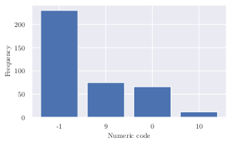

```python
fig, ax = plt.subplots(figsize=set_report_fig_size(fraction=0.7))
ax.bar(unknown_freqs['code'].astype(str), unknown_freqs['frequency']);
ax.set(xlabel="Numeric code", ylabel="Frequency");
fig.savefig(os.path.join(dir_figures, '01_eda_unknown-freqs.pdf'), backend='pgf')
```

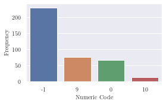

```python
fig, ax = plt.subplots(figsize=set_report_fig_size(fraction=0.6))
sns.barplot(x=unknown_freqs['code'].astype(str), y=unknown_freqs['frequency'], ax=ax);
ax.set(xlabel="Numeric Code", ylabel="Frequency");
fig.savefig(os.path.join(dir_figures, '01_eda_unknown-freqs.pdf'), backend='pgf')
```

### Save the Clean Metadata

```python
# Save clean metadata file
#metadata_df.to_csv(os.path.join(dir_data_processed, 'metadata.csv'), index=False)
```

```python
# Load clean metadata file
metadata_df = pd.read_csv(os.path.join(dir_data_processed, 'metadata.csv'))
```

## Exploration of training data

### Metadata Variables

```python
# Process: get all attributes that have metadata
metadata_attributes = metadata_df['attribute'].unique().tolist()
metadata_numerical = metadata_df.query("type == 'numeric'").attribute.unique().tolist()
metadata_ordinal = metadata_df.query("type == 'ordinal'").attribute.unique().tolist()
metadata_nominal = metadata_df.query("type == 'nominal'").attribute.unique().tolist()
metadata_categorical = metadata_df[metadata_df.type.isin(['ordinal', 'nominal'])].attribute.unique().tolist()
```

### General Stats about Features and Label

```python
# Number of features excluding the response variable and LNR :
mailout_train.shape[1] - 2
```

```
365
```

First, let's examine the data classes and their percentages

```python
ser_response_counts = mailout_train['RESPONSE'].value_counts()
df_response_counts = pd.concat([
                                    ser_response_counts,
                                    np.round(ser_response_counts / ser_response_counts.sum()*100,2)
                               ],
                     axis=1
)

df_response_counts.reset_index(inplace=True)
df_response_counts.columns=['response', 'count', 'percentage']

display(df_response_counts)
```

|  | response | count | percentage |
| --- | --- | --- | --- |
| 0 | 0 | 42430 | 98.76 |
| 1 | 1 | 532 | 1.24 |

```python
save_latex_table(
    df_response_counts,
    path=os.path.join(dir_tables, '02_eda_label-counts.tex'),
    caption="Label Counts and Frequencies",
    label="tab:label-counts-freqs",
    formatter={('percentage'): lambda x: "{:.2f} \%".format(x) }
)
```

```
None
```

### Fix columns that have mixed types

```python
# Printing the names of probelmatic columns
mailout_train.iloc[:,[18,19]].columns
```

```
Index(['CAMEO_DEUG_2015', 'CAMEO_INTL_2015'], dtype='object')
```

```python
mailout_train.iloc[:,18].unique()
```

```
array([5.0, 2.0, 7.0, 4.0, nan, 3.0, 6.0, 1.0, 8.0, 9.0, '4', '6', '2',
       '9', '8', '7', '3', '1', '5', 'X'], dtype=object)
```

```python
mailout_train.iloc[:,19].unique()
```

```
array([34.0, 32.0, 14.0, 41.0, 24.0, 33.0, nan, 25.0, 31.0, 22.0, 43.0,
       13.0, 55.0, 23.0, 54.0, 51.0, 45.0, 12.0, 44.0, 35.0, 15.0, 52.0,
       '23', '44', '14', '55', '51', '45', '43', '22', '54', '24', '25',
       '13', '12', '35', '33', '41', '15', '52', '31', '32', '34', 'XX'],
      dtype=object)
```

It is shown that these two columns have invalid values `X` and `XX` to mark unknown values, so we will replace them with nan and set the dtype of the columns to `float`

```python
# Process: Remove invalid entries in ['CAMEO_DEUG_2015', 'CAMEO_INTL_2015'] and change dtype to float
mailout_train.iloc[:,18].replace('X', np.nan, inplace=True)
mailout_train.iloc[:,19].replace('XX', np.nan, inplace=True)
mailout_train.iloc[:,[18,19]] = mailout_train.iloc[:,[18,19]].astype('float')
```

### Check the cardinality of the categorical featurs (high and low cardinality)

```python
mailout_train.nunique().sort_values(ascending=False).to_frame()
```

|  | 0 |
| --- | --- |
| LNR | 42962 |
| EINGEFUEGT_AM | 1599 |
| KBA13_ANZAHL_PKW | 1230 |
| ANZ_HAUSHALTE_AKTIV | 175 |
| ANZ_STATISTISCHE_HAUSHALTE | 173 |
| ... | ... |
| HH_DELTA_FLAG | 2 |
| OST_WEST_KZ | 2 |
| GREEN_AVANTGARDE | 2 |
| RESPONSE | 2 |
| ANREDE_KZ | 2 |

367 rows × 1 columns

```python
# Process: Drop 'LNR' column as it has unique values:
mailout_train.drop('LNR', axis=1, inplace=True)
```

### Check Dataset Columns that Don't Exist in Metadata and Vice Versa

```python
# Process: Columns that exist in dataset that don't have metadata:
extra_cols_dataset = np.setdiff1d(mailout_train.columns, metadata_attributes)
extra_cols_dataset
```

```
array(['AKT_DAT_KL', 'ALTERSKATEGORIE_FEIN', 'ALTER_KIND1', 'ALTER_KIND2',
       'ALTER_KIND3', 'ALTER_KIND4', 'ANZ_KINDER',
       'ANZ_STATISTISCHE_HAUSHALTE', 'ARBEIT', 'CAMEO_INTL_2015',
       'CJT_KATALOGNUTZER', 'CJT_TYP_1', 'CJT_TYP_2', 'CJT_TYP_3',
       'CJT_TYP_4', 'CJT_TYP_5', 'CJT_TYP_6', 'D19_BANKEN_DIREKT',
       'D19_BANKEN_GROSS', 'D19_BANKEN_LOKAL', 'D19_BANKEN_REST',
       'D19_BEKLEIDUNG_GEH', 'D19_BEKLEIDUNG_REST', 'D19_BILDUNG',
       'D19_BIO_OEKO', 'D19_BUCH_CD', 'D19_DIGIT_SERV',
       'D19_DROGERIEARTIKEL', 'D19_ENERGIE', 'D19_FREIZEIT', 'D19_GARTEN',
       'D19_HANDWERK', 'D19_HAUS_DEKO', 'D19_KINDERARTIKEL',
       'D19_KONSUMTYP_MAX', 'D19_KOSMETIK', 'D19_LEBENSMITTEL',
       'D19_LETZTER_KAUF_BRANCHE', 'D19_LOTTO', 'D19_NAHRUNGSERGAENZUNG',
       'D19_RATGEBER', 'D19_REISEN', 'D19_SAMMELARTIKEL', 'D19_SCHUHE',
       'D19_SONSTIGE', 'D19_SOZIALES', 'D19_TECHNIK', 'D19_TELKO_MOBILE',
       'D19_TELKO_ONLINE_QUOTE_12', 'D19_TELKO_REST', 'D19_TIERARTIKEL',
       'D19_VERSAND_REST', 'D19_VERSICHERUNGEN', 'D19_VERSI_DATUM',
       'D19_VERSI_OFFLINE_DATUM', 'D19_VERSI_ONLINE_DATUM',
       'D19_VERSI_ONLINE_QUOTE_12', 'D19_VOLLSORTIMENT',
       'D19_WEIN_FEINKOST', 'DSL_FLAG', 'EINGEFUEGT_AM',
       'EINGEZOGENAM_HH_JAHR', 'EXTSEL992', 'FIRMENDICHTE', 'GEMEINDETYP',
       'HH_DELTA_FLAG', 'KBA13_ANTG1', 'KBA13_ANTG2', 'KBA13_ANTG3',
       'KBA13_ANTG4', 'KBA13_BAUMAX', 'KBA13_CCM_1401_2500', 'KBA13_GBZ',
       'KBA13_HHZ', 'KBA13_KMH_210', 'KK_KUNDENTYP', 'KOMBIALTER',
       'KONSUMZELLE', 'MOBI_RASTER', 'RESPONSE', 'RT_KEIN_ANREIZ',
       'RT_SCHNAEPPCHEN', 'RT_UEBERGROESSE', 'SOHO_KZ', 'STRUKTURTYP',
       'UMFELD_ALT', 'UMFELD_JUNG', 'UNGLEICHENN_FLAG',
       'VERDICHTUNGSRAUM', 'VHA', 'VHN', 'VK_DHT4A', 'VK_DISTANZ',
       'VK_ZG11'], dtype=object)
```

```python
# Process: Columns that exist in metadata and not in the dataset:
extra_cols_metadata = np.setdiff1d(metadata_attributes, mailout_train.columns)
extra_cols_metadata
```

```
array(['BIP_FLAG', 'CAMEO_DEUINTL_2015', 'D19_BANKEN_DIREKT_RZ',
       'D19_BANKEN_GROSS_RZ', 'D19_BANKEN_LOKAL_RZ', 'D19_BANKEN_REST_RZ',
       'D19_BEKLEIDUNG_GEH_RZ', 'D19_BEKLEIDUNG_REST_RZ',
       'D19_BILDUNG_RZ', 'D19_BIO_OEKO_RZ', 'D19_BUCH_RZ',
       'D19_DIGIT_SERV_RZ', 'D19_DROGERIEARTIKEL_RZ', 'D19_ENERGIE_RZ',
       'D19_FREIZEIT_RZ', 'D19_GARTEN_RZ', 'D19_HANDWERK_RZ',
       'D19_HAUS_DEKO_RZ', 'D19_KINDERARTIKEL_RZ', 'D19_KK_KUNDENTYP',
       'D19_KOSMETIK_RZ', 'D19_LEBENSMITTEL_RZ', 'D19_LOTTO_RZ',
       'D19_NAHRUNGSERGAENZUNG_RZ', 'D19_RATGEBER_RZ', 'D19_REISEN_RZ',
       'D19_SAMMELARTIKEL_RZ', 'D19_SCHUHE_RZ', 'D19_SONSTIGE_RZ',
       'D19_TECHNIK_RZ', 'D19_TELKO_MOBILE_RZ', 'D19_TELKO_REST_RZ',
       'D19_TIERARTIKEL_RZ', 'D19_VERSAND_REST_RZ',
       'D19_VERSICHERUNGEN_RZ', 'D19_VOLLSORTIMENT_RZ',
       'D19_WEIN_FEINKOST_RZ', 'GEOSCORE_KLS7', 'HAUSHALTSSTRUKTUR',
       'KBA13_CCM_1400_2500', 'SOHO_FLAG', 'WACHSTUMSGEBIET_NB'],
      dtype='<U27')
```

> It seems that some common columns between the two sets have different naming, so we rename dataset columns to match the metadata.

```python
# Process: Rename D19 columns in dataset exist in metadata to match metadata, suffix them with _RZ
mailout_train.columns =  mailout_train.columns.map(
                                                  lambda x: re.sub(r"^(D19_.*)$", r"\1_RZ", x)
                                                  if x in np.intersect1d([re.sub(r"_RZ", "", x) for x in extra_cols_metadata], extra_cols_dataset)
                                                  else x
                                                )
```

```python
# Quick comparison between dataset and metadata attribute range of values
# print(mailout_train['CAMEO_INTL_2015'].value_counts().sort_index().index.to_numpy())
# print(metadata_df.query("attribute == 'CAMEO_DEUINTL_2015'")['value'].sort_values().to_numpy())
```

```python
# Process: Manually associate and rename columns
mailout_train.rename(columns={
                                'CAMEO_INTL_2015':'CAMEO_DEUINTL_2015',
                                'KK_KUNDENTYP': 'D19_KK_KUNDENTYP',
                                'KBA13_CCM_1401_2500': 'KBA13_CCM_1400_2500',
                                'D19_BUCH_CD_RZ': 'D19_BUCH_RZ',
                                'SOHO_KZ': 'SOHO_FLAG'
                             },
                             inplace=True)
```

Re examining difference in features between the two sets:

```python
# Columns that exist in dataset that don't have metadata:
np.setdiff1d(mailout_train.columns, metadata_attributes)
```

```
array(['AKT_DAT_KL', 'ALTERSKATEGORIE_FEIN', 'ALTER_KIND1', 'ALTER_KIND2',
       'ALTER_KIND3', 'ALTER_KIND4', 'ANZ_KINDER',
       'ANZ_STATISTISCHE_HAUSHALTE', 'ARBEIT', 'CJT_KATALOGNUTZER',
       'CJT_TYP_1', 'CJT_TYP_2', 'CJT_TYP_3', 'CJT_TYP_4', 'CJT_TYP_5',
       'CJT_TYP_6', 'D19_BUCH_CD', 'D19_KONSUMTYP_MAX',
       'D19_LETZTER_KAUF_BRANCHE', 'D19_SOZIALES',
       'D19_TELKO_ONLINE_QUOTE_12', 'D19_VERSI_DATUM',
       'D19_VERSI_OFFLINE_DATUM', 'D19_VERSI_ONLINE_DATUM',
       'D19_VERSI_ONLINE_QUOTE_12', 'DSL_FLAG', 'EINGEFUEGT_AM',
       'EINGEZOGENAM_HH_JAHR', 'EXTSEL992', 'FIRMENDICHTE', 'GEMEINDETYP',
       'HH_DELTA_FLAG', 'KBA13_ANTG1', 'KBA13_ANTG2', 'KBA13_ANTG3',
       'KBA13_ANTG4', 'KBA13_BAUMAX', 'KBA13_GBZ', 'KBA13_HHZ',
       'KBA13_KMH_210', 'KOMBIALTER', 'KONSUMZELLE', 'MOBI_RASTER',
       'RESPONSE', 'RT_KEIN_ANREIZ', 'RT_SCHNAEPPCHEN', 'RT_UEBERGROESSE',
       'STRUKTURTYP', 'UMFELD_ALT', 'UMFELD_JUNG', 'UNGLEICHENN_FLAG',
       'VERDICHTUNGSRAUM', 'VHA', 'VHN', 'VK_DHT4A', 'VK_DISTANZ',
       'VK_ZG11'], dtype=object)
```

```python
# Columns that exist in metadata and not in the dataset:
np.setdiff1d(metadata_attributes, mailout_train.columns)
```

```
array(['BIP_FLAG', 'D19_BUCH_RZ', 'GEOSCORE_KLS7', 'HAUSHALTSSTRUKTUR',
       'WACHSTUMSGEBIET_NB'], dtype='<U27')
```

Now we have 56 features (Not include `RESPONSE`) that we should manually divide into categorical and numerical features, let's try to guess column type by looking at its unique value count:

```python
mailout_train[np.setdiff1d(mailout_train.columns, metadata_attributes)].nunique().sort_values(ascending=False)
```

```
EINGEFUEGT_AM                 1599
ANZ_STATISTISCHE_HAUSHALTE     173
EXTSEL992                       56
VERDICHTUNGSRAUM                46
D19_LETZTER_KAUF_BRANCHE        35
EINGEZOGENAM_HH_JAHR            33
ALTERSKATEGORIE_FEIN            25
ALTER_KIND1                     17
ALTER_KIND2                     14
VK_DISTANZ                      13
ALTER_KIND3                     12
VK_DHT4A                        11
VK_ZG11                         11
ALTER_KIND4                     11
D19_VERSI_DATUM                 10
D19_VERSI_OFFLINE_DATUM         10
D19_VERSI_ONLINE_DATUM          10
AKT_DAT_KL                       9
D19_BUCH_CD                      8
ANZ_KINDER                       7
GEMEINDETYP                      7
ARBEIT                           6
MOBI_RASTER                      6
RT_UEBERGROESSE                  6
VHA                              6
D19_SOZIALES                     6
D19_KONSUMTYP_MAX                6
KBA13_GBZ                        5
UMFELD_JUNG                      5
UMFELD_ALT                       5
VHN                              5
RT_SCHNAEPPCHEN                  5
RT_KEIN_ANREIZ                   5
KOMBIALTER                       5
KBA13_KMH_210                    5
KBA13_HHZ                        5
CJT_TYP_4                        5
KBA13_BAUMAX                     5
KBA13_ANTG2                      5
CJT_TYP_6                        5
KBA13_ANTG1                      5
CJT_TYP_3                        5
FIRMENDICHTE                     5
CJT_KATALOGNUTZER                5
CJT_TYP_5                        5
CJT_TYP_1                        5
CJT_TYP_2                        5
D19_VERSI_ONLINE_QUOTE_12        4
KBA13_ANTG3                      4
D19_TELKO_ONLINE_QUOTE_12        3
STRUKTURTYP                      3
KBA13_ANTG4                      3
DSL_FLAG                         2
UNGLEICHENN_FLAG                 2
HH_DELTA_FLAG                    2
RESPONSE                         2
KONSUMZELLE                      2
dtype: int64
```

After examining the remaining columns that don't have metadata, We can guess whaich ones are categorical and which ones are numerical

```python
# Process: convert `'EINGEFUEGT_AM'` column that is a date to year column.
mailout_train['EINGEFUEGT_AM'] = mailout_train['EINGEFUEGT_AM'].astype('datetime64[ns]').dt.year
```

```python
# Process: extract numerical and categorical columns.
extra_numerical = [
                    'ALTER_KIND1', 'ALTER_KIND2', 'ALTER_KIND3', 'ALTER_KIND4', 'ANZ_STATISTISCHE_HAUSHALTE',
                    'EINGEFUEGT_AM', 'EINGEZOGENAM_HH_JAHR', 'EXTSEL992', 'VERDICHTUNGSRAUM'
                  ]
extra_nominal = [
                    'AKT_DAT_KL', 'ALTERSKATEGORIE_FEIN', 'ANZ_KINDER', 'ARBEIT', 'CJT_KATALOGNUTZER',
                    'CJT_TYP_1', 'CJT_TYP_2', 'CJT_TYP_3', 'CJT_TYP_4', 'CJT_TYP_5', 'CJT_TYP_6',
                    'D19_BUCH_CD', 'D19_KONSUMTYP_MAX',
                    'D19_LETZTER_KAUF_BRANCHE', 'D19_SOZIALES',
                    'D19_TELKO_ONLINE_QUOTE_12', 'D19_VERSI_DATUM',
                    'D19_VERSI_OFFLINE_DATUM', 'D19_VERSI_ONLINE_DATUM',
                    'D19_VERSI_ONLINE_QUOTE_12', 'DSL_FLAG', 'FIRMENDICHTE', 'GEMEINDETYP',
                    'HH_DELTA_FLAG', 'KOMBIALTER', 'KONSUMZELLE', 'MOBI_RASTER',
                    'RT_KEIN_ANREIZ', 'RT_SCHNAEPPCHEN', 'RT_UEBERGROESSE',
                    'STRUKTURTYP', 'UMFELD_ALT', 'UMFELD_JUNG', 'UNGLEICHENN_FLAG',
                    'VHA', 'VHN', 'VK_DHT4A', 'VK_DISTANZ', 'VK_ZG11'
                    ]

extra_ordinal = ['KBA13_ANTG1', 'KBA13_ANTG2', 'KBA13_ANTG3',
                    'KBA13_ANTG4', 'KBA13_BAUMAX', 'KBA13_GBZ', 'KBA13_HHZ',
                    'KBA13_KMH_210']
```

```python
len(extra_numerical + extra_nominal + extra_ordinal)
```

```
56
```

```python
# Get a list of all features of the dataset before dropping any features.
dataset_all_features = mailout_train.columns.to_list()
dataset_all_features.remove('RESPONSE')
```

### Check Categorical Columns in the Dataset against Metadata Valid Ranges

In this step we check the categorical columns in the dataset agianst the metadata valid range of values, and replace invalid values with `np.nan`

```python
# Process: Drop unknown values from metadta frame, as all invalid values not found in metadata will be replaced by np.nan
metadata_df.drop(metadata_df.query("meaning == 'unknown'").index, inplace=True)
```

```python
def replace_invalid_values(series, metadata_df):
    series = series.copy()
    col_name = series.name
    col_dtype = series.dtype
    valid_metadata_ranges = metadata_df.query(f"attribute == '{col_name}'")['value'].to_numpy().astype(col_dtype)

    if col_dtype == object:
        dataset_ranges = series.fillna('NULL').unique().astype(col_dtype)
    else:
        dataset_ranges = series.unique().astype(col_dtype)

    invalid_values = np.setdiff1d(
                                dataset_ranges,
                                valid_metadata_ranges
                    )
    series.replace(invalid_values, np.nan, inplace=True)

    return series
```

```python
# Process: find categorical features that exist in both the dataset and metadata.
dataset_meta_categorical = np.intersect1d(mailout_train.columns, metadata_categorical)
```

```python
# Process: find and replace invalid values with np.nan
mailout_train[dataset_meta_categorical] = mailout_train[dataset_meta_categorical].apply(replace_invalid_values, metadata_df=metadata_df)
```

```python
mailout_train.shape
```

```
(42962, 366)
```

```python
mailout_train.isna().sum().sum()
```

```
4262045
```

### Explore Features That Have a High Percentage of Missing Values (>30% missing)

```python
missing_threshold = 0.3

missing_columns_freqs = (mailout_train.isna().sum() / mailout_train.shape[0]).sort_values(ascending = False)

missing_data_cols = missing_columns_freqs[missing_columns_freqs > missing_threshold]
missing_data_cols.index.tolist()
```

```
['ALTER_KIND4',
 'ALTER_KIND3',
 'TITEL_KZ',
 'D19_TELKO_ONLINE_DATUM',
 'ALTER_KIND2',
 'D19_BANKEN_LOKAL_RZ',
 'D19_BANKEN_ONLINE_QUOTE_12',
 'D19_BANKEN_OFFLINE_DATUM',
 'D19_DIGIT_SERV_RZ',
 'D19_TELKO_ANZ_12',
 'ALTER_KIND1',
 'D19_TIERARTIKEL_RZ',
 'D19_BANKEN_ANZ_12',
 'D19_BANKEN_REST_RZ',
 'D19_GARTEN_RZ',
 'D19_TELKO_ANZ_24',
 'D19_VERSI_ANZ_12',
 'D19_TELKO_OFFLINE_DATUM',
 'D19_ENERGIE_RZ',
 'D19_BANKEN_GROSS_RZ',
 'D19_BANKEN_ANZ_24',
 'D19_NAHRUNGSERGAENZUNG_RZ',
 'D19_BIO_OEKO_RZ',
 'D19_TELKO_REST_RZ',
 'D19_FREIZEIT_RZ',
 'D19_SCHUHE_RZ',
 'D19_VERSI_ANZ_24',
 'D19_LEBENSMITTEL_RZ',
 'D19_WEIN_FEINKOST_RZ',
 'D19_BANKEN_ONLINE_DATUM',
 'D19_BANKEN_DIREKT_RZ',
 'D19_DROGERIEARTIKEL_RZ',
 'D19_VERSAND_REST_RZ',
 'D19_TELKO_MOBILE_RZ',
 'D19_BEKLEIDUNG_GEH_RZ',
 'D19_RATGEBER_RZ',
 'D19_BILDUNG_RZ',
 'D19_BANKEN_DATUM',
 'D19_KINDERARTIKEL_RZ',
 'D19_TELKO_DATUM',
```

[output cut: 12 more lines]

```
 'D19_GESAMT_ANZ_12',
 'D19_KK_KUNDENTYP',
 'D19_VERSAND_ANZ_24',
 'KBA05_BAUMAX',
 'D19_VERSAND_ONLINE_DATUM',
 'D19_GESAMT_ANZ_24',
 'D19_VOLLSORTIMENT_RZ',
 'D19_VERSAND_OFFLINE_DATUM',
 'D19_GESAMT_ONLINE_DATUM',
 'D19_GESAMT_OFFLINE_DATUM',
 'AGER_TYP',
 'EXTSEL992',
 'D19_SONSTIGE_RZ',
 'D19_VERSAND_DATUM',
 'ALTER_HH']
```

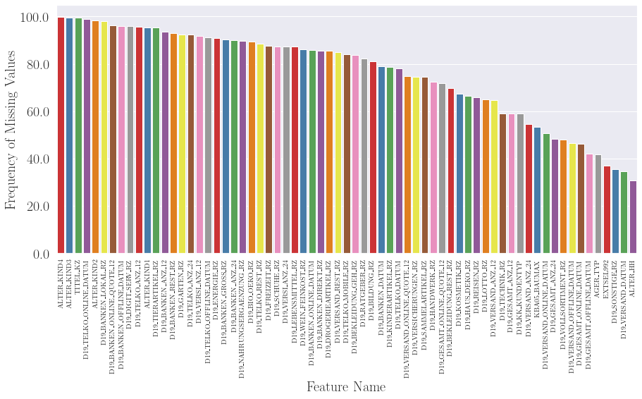

```python
with mpl.rc_context(
{
    "axes.labelsize": 20,
    "ytick.labelsize": 20,

}
):
    fig, ax = plt.subplots(figsize=set_report_fig_size(fraction=2))
    sns.barplot(x=missing_data_cols.index, y=missing_data_cols * 100, ax=ax, palette='Set1');
    ax.set(xlabel="Feature Name", ylabel="Frequency of Missing Values");
    ax.yaxis.set_major_formatter(lambda x, pos: str(x) + '%')
    ax.tick_params(axis='x', rotation=90);
    fig.savefig(os.path.join(dir_figures, '03_missing-values.pdf'), backend='pgf')
```

There are 67 columns with missing values > 30%

```python
# Drop columns that have missing > 30%
mailout_train = mailout_train.drop(missing_data_cols.index, axis=1)
```

```python
mailout_train.shape
```

```
(42962, 299)
```

### Explore highly correlated features

```python
corr_threshold = 0.6
```

```python
correlation_matrix = mailout_train[
    np.intersect1d(mailout_train.columns, metadata_ordinal + metadata_numerical + extra_ordinal + extra_numerical)
].corr().abs()
```

```python
correlation_matrix
```

|  | ANZ_HAUSHALTE_AKTIV | ANZ_HH_TITEL | ANZ_PERSONEN | ANZ_STATISTISCHE_HAUSHALTE | ANZ_TITEL | BALLRAUM | D19_GESAMT_DATUM | EINGEFUEGT_AM | EINGEZOGENAM_HH_JAHR | EWDICHTE | ... | SEMIO_PFLICHT | SEMIO_RAT | SEMIO_REL | SEMIO_SOZ | SEMIO_TRADV | SEMIO_VERT | VERDICHTUNGSRAUM | WOHNDAUER_2008 | WOHNLAGE | W_KEIT_KIND_HH |
| --- | --- | --- | --- | --- | --- | --- | --- | --- | --- | --- | --- | --- | --- | --- | --- | --- | --- | --- | --- | --- | --- |
| ANZ_HAUSHALTE_AKTIV | 1.000000 | 0.495912 | 0.130954 | 0.990089 | 0.001073 | 0.220637 | 0.085777 | 0.026716 | 0.118230 | 0.276100 | ... | 0.044310 | 0.022660 | 0.053701 | 0.028584 | 0.048910 | 0.072203 | 0.054003 | 0.088016 | 0.084513 | 0.119335 |
| ANZ_HH_TITEL | 0.495912 | 1.000000 | 0.040457 | 0.512164 | 0.263144 | 0.085969 | 0.018996 | 0.002394 | 0.068625 | 0.098551 | ... | 0.022681 | 0.002400 | 0.015859 | 0.019537 | 0.012009 | 0.024877 | 0.020127 | 0.055677 | 0.041208 | 0.034458 |
| ANZ_PERSONEN | 0.130954 | 0.040457 | 1.000000 | 0.134667 | 0.039925 | 0.130304 | 0.337653 | 0.007940 | 0.165871 | 0.179151 | ... | 0.108126 | 0.095736 | 0.124704 | 0.037836 | 0.115093 | 0.070132 | 0.035926 | 0.122542 | 0.091926 | 0.622053 |
| ANZ_STATISTISCHE_HAUSHALTE | 0.990089 | 0.512164 | 0.134667 | 1.000000 | 0.000489 | 0.211770 | 0.088777 | 0.022874 | 0.122727 | 0.266411 | ... | 0.046297 | 0.025087 | 0.055933 | 0.026333 | 0.051800 | 0.072741 | 0.051867 | 0.090410 | 0.082135 | 0.119325 |
| ANZ_TITEL | 0.001073 | 0.263144 | 0.039925 | 0.000489 | 1.000000 | 0.019323 | 0.025313 | 0.007455 | 0.004296 | 0.019768 | ... | 0.003010 | 0.001578 | 0.024845 | 0.018082 | 0.014076 | 0.023687 | 0.013876 | 0.013188 | 0.025795 | 0.006426 |
| ... | ... | ... | ... | ... | ... | ... | ... | ... | ... | ... | ... | ... | ... | ... | ... | ... | ... | ... | ... | ... | ... |
| SEMIO_VERT | 0.072203 | 0.024877 | 0.070132 | 0.072741 | 0.023687 | 0.073882 | 0.025370 | 0.054991 | 0.080143 | 0.074793 | ... | 0.336298 | 0.382651 | 0.243654 | 0.574502 | 0.002393 | 1.000000 | 0.001774 | 0.035859 | 0.031029 | 0.018641 |
| VERDICHTUNGSRAUM | 0.054003 | 0.020127 | 0.035926 | 0.051867 | 0.013876 | 0.064530 | 0.029043 | 0.029016 | 0.012417 | 0.292045 | ... | 0.014140 | 0.009861 | 0.002211 | 0.022887 | 0.013498 | 0.001774 | 1.000000 | 0.009260 | 0.151177 | 0.032907 |
| WOHNDAUER_2008 | 0.088016 | 0.055677 | 0.122542 | 0.090410 | 0.013188 | 0.031737 | 0.010724 | 0.165166 | 0.658516 | 0.044517 | ... | 0.045167 | 0.043363 | 0.021035 | 0.033132 | 0.023724 | 0.035859 | 0.009260 | 1.000000 | 0.022871 | 0.039839 |
| WOHNLAGE | 0.084513 | 0.041208 | 0.091926 | 0.082135 | 0.025795 | 0.332363 | 0.066946 | 0.078421 | 0.000595 | 0.564059 | ... | 0.023817 | 0.032319 | 0.048064 | 0.034361 | 0.034121 | 0.031029 | 0.151177 | 0.022871 | 1.000000 | 0.090428 |
| W_KEIT_KIND_HH | 0.119335 | 0.034458 | 0.622053 | 0.119325 | 0.006426 | 0.104043 | 0.305088 | 0.056120 | 0.018290 | 0.161391 | ... | 0.181021 | 0.186146 | 0.154057 | 0.007254 | 0.169232 | 0.018641 | 0.032907 | 0.039839 | 0.090428 | 1.000000 |

231 rows × 231 columns

```python
# Select upper triangle of correlation matrix
upper_corr_mat = correlation_matrix.where(
    np.triu(np.ones(correlation_matrix.shape), k=1).astype(bool))
```

```python
corr_to_drop = upper_corr_mat.columns[(upper_corr_mat > corr_threshold).any(axis='rows')].tolist()
#corr_to_drop = upper_corr_mat.index[(upper_corr_mat > corr_threshold).any(axis='columns')].tolist()
```

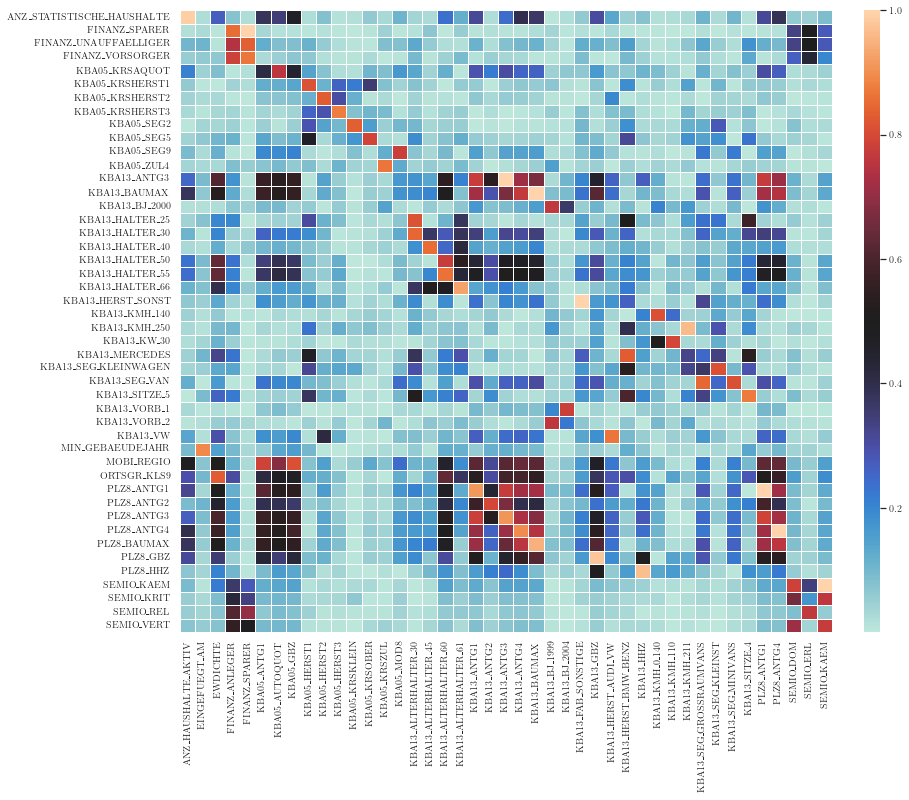

```python
# Draw a heat map for features that have > 0.75 correlation
heatmap_rows = upper_corr_mat.columns[(upper_corr_mat > 0.75).any(axis='rows')].tolist()
heatmap_cols = upper_corr_mat.index[(upper_corr_mat > 0.75).any(axis='columns')].tolist()
heatmap = correlation_matrix.loc[heatmap_rows,heatmap_cols]


fig, ax = plt.subplots(figsize=(2 * set_report_fig_size(fraction=1)[0], 2 *  5.5))
ax = sns.heatmap(heatmap, center=0.5, linewidths=.5, ax=ax, cbar_kws={'aspect':40})
fig.savefig(os.path.join(dir_figures, '04_correlation-heatmap.pdf'), backend='pgf')
```

```python
# Drop correlated features
mailout_train = mailout_train.drop(corr_to_drop, axis=1)
```

```python
mailout_train.shape
```

```
(42962, 201)
```

### Find and Drop Duplicated Rows

```python
missing_mean = mailout_train.duplicated().mean()
```

```python
print("Percentage of duplicated rows: {:.2f}%".format(missing_mean * 100))
```

```
Percentage of duplicated rows: 13.41%
```

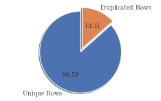

```python
labels = 'Unique Rows', 'Duplicated Rows'
sizes = [1 - missing_mean, missing_mean]
explode = (0, 0.1)  # only "explode" the 2nd slice (i.e. 'Hogs')

fig, ax = plt.subplots(figsize=set_report_fig_size(fraction=.5))
ax.pie(sizes, explode=explode, labels=labels, autopct=r"%1.2f%%",
        shadow=True, startangle=90)
ax.axis('equal')  # Equal aspect ratio ensures that pie is drawn as a circle.
fig.savefig(os.path.join(dir_figures, '05_eda_missing-rows.pdf'), format='pdf', bbox_inches='tight')
```

```python
# Drop duplicate rows
mailout_train.drop_duplicates(inplace=True)
```

### Find and Remove outliers

```python
def get_outliers(s):
    mean , std = s.mean(), s.std()
    cutoff = 3 * std
    return ~ s.between(mean - cutoff, mean + cutoff) # a series that has True in place of outliers
```

```python
numerical_df = mailout_train[np.intersect1d(mailout_train.columns, metadata_numerical + extra_numerical)]
```

```python
outlier_percent_per_feature = (numerical_df.apply(get_outliers).sum() / numerical_df.shape[0] * 100)\
                                .to_frame()\
                                .reset_index()\
                                .rename({'index': 'feature', 0: 'percentage of outliers'}, axis=1)

display(outlier_percent_per_feature)

save_latex_table(
    outlier_percent_per_feature,
    path=os.path.join(dir_tables, '03_eda_outlier-percent-per-feature.tex'),
    caption="Percentage of outliers for each numerical feature",
    label="tab:outlier-percent",
    formatter={
        ('percentage of outliers'): lambda x: "{:.2f}\%".format(x),
        ('feature'): lambda x: x.replace("_", "\_")
    }
)
```

|  | feature | percentage of outliers |
| --- | --- | --- |
| 0 | ANZ_HAUSHALTE_AKTIV | 6.806452 |
| 1 | ANZ_HH_TITEL | 7.198925 |
| 2 | ANZ_PERSONEN | 3.881720 |
| 3 | ANZ_TITEL | 4.107527 |
| 4 | EINGEFUEGT_AM | 9.379032 |
| 5 | EINGEZOGENAM_HH_JAHR | 3.338710 |
| 6 | GEBURTSJAHR | 0.000000 |
| 7 | KBA13_ANZAHL_PKW | 7.247312 |
| 8 | VERDICHTUNGSRAUM | 9.271505 |

```
None
```

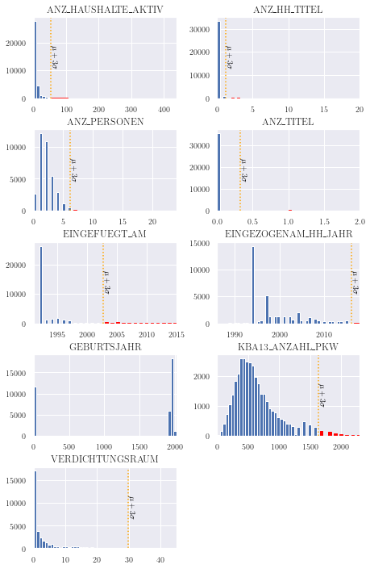

```python
set_bar_color = np.vectorize(lambda x: x.set_color('red'))

fig, ax = plt.subplots(5,2,figsize=set_report_fig_size(fraction=1,subplots=(5, 2)))
for i, (name, s) in enumerate(numerical_df.iteritems()):
    mean, std = s.mean(), s.std()
    cutoff_min, cutoff_max = mean - 3 * std, mean + 3 * std

    sub_ax = ax.flatten()[i]
    frqs, bins, bars = sub_ax.hist(s, bins=50);

    outlier_bars = np.logical_or(bins > cutoff_max, bins < cutoff_min)[:-1]
    if outlier_bars.any():
        set_bar_color(np.array(bars)[outlier_bars])

    sub_ax.axvline(cutoff_min, color='orange', linestyle='dotted');
    sub_ax.axvline(cutoff_max, color='orange', linestyle='dotted');
    sub_ax.set_xlim(s.min(), s.max());
    sub_ax.set_title(s.name)

    trans = transforms.blended_transform_factory(
        sub_ax.transData, sub_ax.transAxes)

    # If outlier line is not outside the axis area, draw text
    if sub_ax.transData.transform((cutoff_max, 0))[0] < sub_ax.transAxes.transform((1, 0))[0]:
        sub_ax.text(cutoff_max, 0.5, r'$\mu + 3\sigma$',
                    verticalalignment='center',
    #                horizontalalignment='right',
                    transform=trans,
                    color='black',
                    rotation=270
                   )
for j in range(i+1, ax.flatten().shape[0]):
    ax.flatten()[j].axis('off')
fig.savefig(os.path.join(dir_figures, '06_eda_outliers.pdf'), backend='pgf')
```

## Summary of Dataset Feature Types

```python
from metadata import Metadata
```

```python
metadata = Metadata(os.path.join(dir_data_processed, 'metadata.csv'))
metadata.df_lookup.set_index('attribute', drop=False, inplace=True)
```

```python
df_metadata_stats = metadata.df_lookup.loc[dataset_all_features]\
                    .groupby(['type', 'dataset'])\
                    .count().reset_index()\
                    .rename({'attribute': 'frequency', 'dataset': 'subset'}, axis=1)
```

```python
df_metadata_stats
```

|  | type | subset | frequency |
| --- | --- | --- | --- |
| 0 | nominal | extra | 39 |
| 1 | nominal | metadata | 64 |
| 2 | numeric | extra | 9 |
| 3 | numeric | metadata | 7 |
| 4 | ordinal | extra | 8 |
| 5 | ordinal | metadata | 238 |

```python
save_latex_table(
    df_metadata_stats,
    path=os.path.join(dir_tables, '03_eda_feature-types-stats.tex'),
    caption="Dataset feature types",
    label="tab:dataset-feature-types",
)
```

```
None
```

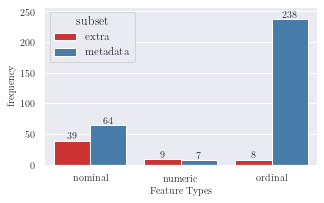

```python
fig, ax = plt.subplots(figsize=set_report_fig_size(fraction=0.7))
g = sns.barplot(
    x='type', y='frequency', hue='subset', data=df_metadata_stats,
    palette="Set1",
    ax=ax
)
g.set_ylim(top=df_metadata_stats['frequency'].max() + 20)
g.set_xlabel('Feature Types')
for container in g.containers:
    g.bar_label(container)
fig.savefig(os.path.join(dir_figures, '07_feature-types.pdf'), backend='pgf')
```

## Putting all Preprocessing Steps Together

In the next notebook 02_data-processing-pipeline.ipynb, we will package all the preprocessing steps from this notebook into Scikit-Learn Transformers.